# Unsupervised Methods

# Different Types of Distances in Cluster Analysis

In cluster analysis, **distance measures how different or dissimilar two observations are**. Observations with smaller distances are generally considered more similar, while those with larger distances are considered less similar.

For example, an e-commerce company may group customers based on their spending habits. The distance measure helps determine which customers have similar purchasing behavior.

The choice of distance measure depends on the type of data being analyzed.

Four important measures: **Euclidean distance, Manhattan distance, Hamming distance, and cosine similarity**. unsupervised

Let’s understand each with simple examples and R code.

## 1. Euclidean distance

**Euclidean distance is the straight-line distance between two points.**

It is commonly used with numerical data, such as customer spending, student marks, and product measurements.

### Example

Suppose two students have the following marks:

| Student | Mathematics | Statistics |
| --- | --- | --- |
| A | 60 | 70 |
| B | 63 | 74 |

The Euclidean distance is:

$$d(A,B)=\sqrt{(60-63)^2+(70-74)^2}$$
$$=\sqrt{9+16}$$

$$=\sqrt{25}=\boxed{5}$$

The Euclidean distance between the two students is **5**.

### R code

```r
# Marks of two students
A <- c(60, 70)
B <- c(63, 74)

# Calculate Euclidean distance
sqrt(sum((A - B)^2))
```

```
## [1] 5
```

**Output**

```
[1] 5
```

We can also use R’s built-in `dist()` function:

```r
students <- data.frame(
  Mathematics = c(60, 63),
  Statistics = c(70, 74)
)

dist(students, method = "euclidean")
```

```
##   1
## 2 5
```

**Output**

```
  1
2 5
```

Here, the output represents the distance between the first and second rows.

**Industry application:** A retailer can use Euclidean distance to compare customers based on numerical attributes such as annual spending and purchase frequency. If the variables have very different scales, standardization may be necessary before calculating distances.

## 2. Manhattan distance

**Manhattan distance is the sum of the absolute differences between corresponding values.**

Imagine walking through city streets arranged in a grid. You may need to travel along horizontal and vertical roads rather than take a straight-line route. Manhattan distance represents this type of distance.

### Example

Consider the same two students:

| Student | Mathematics | Statistics |
| --- | --- | --- |
| A | 60 | 70 |
| B | 63 | 74 |

The Manhattan distance is:

$$d(A,B)=|60-63|+|70-74|$$

$$=3+4=\boxed{7}$$

Notice the difference:

- Euclidean distance = 5
- Manhattan distance = 7

Both measures compare the same students, but they calculate distance differently.

### R code

```r
A <- c(60, 70)
B <- c(63, 74)

# Manhattan distance
sum(abs(A - B))
```

```
## [1] 7
```

**Output**

```
[1] 7
```

Using `dist()`:

```r
students <- data.frame(
  Mathematics = c(60, 63),
  Statistics = c(70, 74)
)

dist(students, method = "manhattan")
```

```
##   1
## 2 7
```

**Output**

```
  1
2 7
```

**Industry application:** Manhattan distance can be useful in grid-based logistics problems, where travel follows horizontal and vertical routes. However, actual road-network distances are best calculated from the road network itself.

### Euclidean versus Manhattan distance

| Feature | Euclidean | Manhattan |
| --- | --- | --- |
| Calculation | Straight-line distance | Sum of absolute differences |
| Formula | Square root of the sum of squared differences | Sum of absolute differences |
| Example result | 5 | 7 |
| Common application | Numerical data clustering | Numerical data clustering and grid-based distance problems |

## 3. Hamming distance

**Hamming distance counts the number of positions at which two sequences of equal length differ.**

It is particularly useful for comparing binary values and categorical sequences.

### Example 1: Comparing binary sequences

Suppose two products have the following feature representations:

- Product A: `10110`
- Product B: `10011`

Compare the sequences position by position:

| Position | Product A | Product B | Different? |
| --- | --- | --- | --- |
| 1 | 1 | 1 | No |
| 2 | 0 | 0 | No |
| 3 | 1 | 0 | Yes |
| 4 | 1 | 1 | No |
| 5 | 0 | 1 | Yes |

There are two positions where the values differ.

Therefore:

$$d_H(A,B)=\boxed{2}$$

### R code

```r
A <- c(1, 0, 1, 1, 0)
B <- c(1, 0, 0, 1, 1)

sum(A != B)
```

```
## [1] 2
```

**Output**

```
[1] 2
```

The expression `A != B` compares the values at each position. The function `sum()` counts how many comparisons are `TRUE`.

### Example 2: Comparing categorical data

Suppose two customers have the following preferences:

| Attribute | Customer A | Customer B |
| --- | --- | --- |
| Preferred payment | UPI | UPI |
| Preferred device | Mobile | Laptop |
| Membership | Gold | Silver |

The payment preferences match, but the device and membership differ.

The Hamming distance is:

$$d_H(A,B)=\boxed{2}$$

R code:

```r
A <- c("UPI", "Mobile", "Gold")
B <- c("UPI", "Laptop", "Silver")

sum(A != B)
```

```
## [1] 2
```

Output:

```
[1] 2
```

**Important:** Hamming distance counts mismatches; it does not consider how different the categories are. It also requires sequences of equal length.

**Industry application:** Hamming distance can compare binary product features, digital communication sequences, and fixed-length categorical records.

## 4. Cosine similarity

Cosine similarity is slightly different from the previous measures. It measures the **similarity in direction between two vectors**, rather than their absolute distance.

It is commonly used in text mining and document comparison.

### Example: Comparing two documents

Suppose a text-analysis system represents two documents using word counts for three words: *data*, *science*, and *AI*.

| Word | Document A | Document B |
| --- | --- | --- |
| Data | 2 | 4 |
| Science | 1 | 2 |
| AI | 0 | 0 |

The vectors are:

$$A=(2,1,0)$$

$$B=(4,2,0)$$

Document B has twice the word counts of Document A, but both have the same relative proportions.

Cosine similarity is calculated as:

$$\operatorname{cosine}(A,B)=
\frac{A\cdot B}{\|A\|\|B\|}$$

Expanding the formula:

$$=\frac{(2\times4)+(1\times2)+(0\times0)}
{\sqrt{2^2+1^2+0^2}\sqrt{4^2+2^2+0^2}}$$

$$=\frac{10}{\sqrt{5}\sqrt{20}}$$

$$=\boxed{1}$$

A cosine similarity of 1 means the two nonzero vectors point in exactly the same direction.

### R code

```r
A <- c(2, 1, 0)
B <- c(4, 2, 0)

cosine_similarity <- sum(A * B) /
  (sqrt(sum(A^2)) * sqrt(sum(B^2)))

cosine_similarity
```

```
## [1] 1
```

**Output**

```
[1] 1
```

### How do we interpret cosine similarity?

| Cosine similarity | General interpretation |
| --- | --- |
| 1 | Same direction |
| 0 | Orthogonal vectors, meaning no directional similarity |
| -1 | Opposite directions |

These interpretations assume nonzero vectors. For ordinary nonnegative word-count vectors, cosine similarity ranges from 0 to 1.

**Industry application:** A search engine can compare a user’s search query with documents and rank documents by their cosine similarity to the query representation.

### Is cosine similarity a distance?

Strictly speaking, cosine similarity is a similarity measure, not a distance.

A commonly used corresponding dissimilarity is:

$$d_{\text{cosine}}=1-\operatorname{cosine}(A,B)$$

For our example:

$$d_{\text{cosine}}=1-1=\boxed{0}$$

The value is zero because the vectors point in the same direction.

R code:

```r
cosine_distance <- 1 - cosine_similarity

cosine_distance
```

```
## [1] 2.220446e-16
```

Output:

[output not shown]

Be aware that $1-\text{cosine similarity}$ is commonly called cosine distance, but it is not a true mathematical metric in every setting.

## 5. Minkowski distance

Minkowski distance is a general formula that includes both Euclidean and Manhattan distances as special cases.

Its formula is:

$$d(A,B)=\left(\sum_{i=1}^{n}|A_i-B_i|^p\right)^{1/p}$$

Here, $p$ determines the type of distance.

- When $p=1$, it becomes Manhattan distance.
- When $p=2$, it becomes Euclidean distance.

### Example

Consider:

$$A=(60,70), \qquad B=(63,74)$$

For $p=1$:

$$d(A,B)=|60-63|+|70-74|=7$$

For $p=2$:

$$d(A,B)=\sqrt{(60-63)^2+(70-74)^2}=5$$

### R code

```r
A <- c(60, 70)
B <- c(63, 74)

# Minkowski distance with p = 1
sum(abs(A - B)^1)^(1/1)
```

```
## [1] 7
```

```r
# Minkowski distance with p = 2
sum(abs(A - B)^2)^(1/2)
```

```
## [1] 5
```

Output:

```
[1] 7
[1] 5
```

**Industry application:** Minkowski distance provides flexibility when comparing numerical observations. Choosing an appropriate value of $p$ changes how differences contribute to the distance.

## 6. Comparing the distance and similarity measures

Using the examples above:

| Measure | Example | Result | What does it tell us? |
| --- | --- | --- | --- |
| Euclidean distance | Student marks | 5 | Straight-line distance |
| Manhattan distance | Student marks | 7 | Sum of absolute differences |
| Hamming distance | Binary sequences | 2 | Number of mismatched positions |
| Cosine similarity | Document vectors | 1 | The vectors have the same direction |
| Cosine dissimilarity | Document vectors | 0 | No directional difference |
| Minkowski distance, $p=1$ | Student marks | 7 | Equivalent to Manhattan distance |
| Minkowski distance, $p=2$ | Student marks | 5 | Equivalent to Euclidean distance |

## 7. How do we choose a distance measure?

| Data or problem | Possible measure | Example |
| --- | --- | --- |
| Numerical measurements | Euclidean | Comparing students’ marks |
| Numerical measurements where absolute differences are useful | Manhattan | Comparing customer attributes |
| Binary sequences or equal-length categorical sequences | Hamming | Comparing product features |
| Text vectors or document representations | Cosine similarity | Search engines |
| Numerical data requiring a flexible distance formula | Minkowski | Comparing numerical observations |

These are general guidelines rather than strict rules. The best measure depends on the meaning of the variables and the clustering objective.

# K-Means Clustering

K-means is one of the most widely used **unsupervised machine learning algorithms**. It groups similar data points into clusters without requiring predefined class labels.

Let’s understand it through an industry example, a small dataset, and simple R code.

## 1. What is K-means clustering?

Imagine an e-commerce company such as Amazon wants to divide its customers into groups based on their purchasing behavior.

The company has information about each customer’s:

- Annual spending
- Number of purchases per year

It wants to identify groups such as:

- **Cluster 1:** Customers who spend less and purchase less frequently.
- **Cluster 2:** Customers who spend moderately and purchase moderately.
- **Cluster 3:** Customers who spend more and purchase frequently.

Instead of manually assigning customers to groups, the company uses K-means clustering to discover groups with similar purchasing patterns.

**K-means automatically groups similar observations into K clusters.**

Here, **K is the number of clusters we want to create**, and we choose it before running the algorithm.

For example:

- K = 2 → two clusters
- K = 3 → three clusters
- K = 5 → five clusters

K-means is called an *unsupervised* learning algorithm because the data does not need predefined labels such as “low spender” or “high spender.”

## 2. How does K-means work?

K-means follows an iterative process.

### Step 1: Choose the number of clusters (K)

Suppose an online store wants to divide its customers into three groups.

We choose:

`K = 3`

### Step 2: Initialize the centroids

A **centroid** is the center of a cluster.

Initially, the algorithm selects three centroids, usually from randomly chosen positions or observations.

Think of each centroid as a temporary representative of a group.

### Step 3: Assign each observation to its nearest centroid

For every customer, the algorithm calculates the distance to each centroid.

The customer is assigned to the cluster with the nearest centroid.

For example, if a customer is closer to Centroid 2 than to Centroids 1 and 3, that customer is assigned to Cluster 2.

K-means commonly uses **Euclidean distance** for this assignment.

For two observations with values $(x_1,y_1)$ and $(x_2,y_2)$, the Euclidean distance is:

$$d=\sqrt{(x_1-x_2)^2+(y_1-y_2)^2}$$

### Step 4: Recalculate the centroids

After assigning the observations, the algorithm calculates the mean of each cluster.

For example, suppose a cluster contains three customers with annual spending values:

$$10,\quad 20,\quad 30$$

The new centroid for spending is:

$$\frac{10+20+30}{3}=20$$

The centroid is updated using the means of the observations assigned to that cluster.

### Step 5: Repeat the process

The algorithm repeats these two operations:

1. Assign observations to their nearest centroids.
2. Recalculate the centroids.

It continues until the assignments or centroids stop changing significantly, or a stopping condition is reached.

**In simple words: K-means repeatedly assigns points to their nearest group center and moves each group center to the mean of its assigned points.**

## 3. A small numerical example

Suppose a company wants to group six customers based on their annual spending (in thousands of rupees).

| Customer | Annual spending (₹ thousands) |
| --- | --- |
| A | 10 |
| B | 12 |
| C | 15 |
| D | 60 |
| E | 65 |
| F | 70 |

Assume we choose **K = 2**.

The algorithm may discover the following clusters:

| Cluster | Customers | Average spending |
| --- | --- | --- |
| Cluster 1 | A, B, C | 12.33 |
| Cluster 2 | D, E, F | 65.00 |

The algorithm has separated the customers into two groups based on their spending.

Notice that we did not tell the algorithm which customers are low spenders or high spenders. It discovered the groups from the data.

In this simple example, the groups are easy to recognize because the spending values are clearly separated.

## 4. Industry applications of K-means

K-means is used in several industries.

| Industry | Data used | Possible clustering application |
| --- | --- | --- |
| E-commerce | Purchase amount, purchase frequency | Customer segmentation |
| Banking | Transaction amount, transaction frequency | Identifying groups with similar transaction behavior |
| Telecom | Call duration, data usage, monthly spending | Customer usage segmentation |
| Healthcare | Measurements and patient characteristics | Exploratory grouping of patients |
| Manufacturing | Temperature, vibration, pressure | Grouping similar operating conditions |
| Education | Attendance, assignment scores, exam marks | Identifying students with similar performance patterns |

**Important:** A cluster does not automatically have a meaningful label. After clustering, domain experts must interpret the groups. For example, a company might discover a group of customers who spend frequently but make small purchases.

## 5. Implementing K-means in R

Let’s implement K-means using the six customers from our example.

### Step 1: Create the dataset

```r
customer <- data.frame(
  Customer = c("A", "B", "C", "D", "E", "F"),
  Spending = c(10, 12, 15, 60, 65, 70)
)

customer
```

| Customer | Spending |
| --- | --- |
| A | 10 |
| B | 12 |
| C | 15 |
| D | 60 |
| E | 65 |
| F | 70 |

### Step 2: Apply K-means

```r
set.seed(123)

model <- kmeans(
  customer["Spending"],
  centers = 2,
  nstart = 25
)

model
```

```
## K-means clustering with 2 clusters of sizes 3, 3
##
## Cluster means:
##   Spending
## 1 12.33333
## 2 65.00000
##
## Clustering vector:
## [1] 1 1 1 2 2 2
##
## Within cluster sum of squares by cluster:
## [1] 12.66667 50.00000
##  (between_SS / total_SS =  98.5 %)
##
## Available components:
##
## [1] "cluster"      "centers"      "totss"        "withinss"     "tot.withinss"
## [6] "betweenss"    "size"         "iter"         "ifault"
```

Let’s understand the important arguments:

| Argument | Meaning |
| --- | --- |
| `customer["Spending"]` | The variable used to group customers |
| `centers = 2` | Create two clusters |
| `nstart = 25` | Try 25 different initial centroid configurations and retain the best solution found |
| `set.seed(123)` | Makes the random initialization reproducible |

The algorithm assigns each customer to a cluster.

### Step 3: Display the cluster assignments

```r
customer$Cluster <- model$cluster

customer
```

| Customer | Spending | Cluster |
| --- | --- | --- |
| A | 10 | 1 |
| B | 12 | 1 |
| C | 15 | 1 |
| D | 60 | 2 |
| E | 65 | 2 |
| F | 70 | 2 |

The cluster numbers might be 1 and 2, but the numbers themselves have no special meaning. Cluster 1 is not necessarily better or more important than Cluster 2.

### Step 4: Display the cluster centers

```r
model$centers
```

```
##   Spending
## 1 12.33333
## 2 65.00000
```

The output shows the mean spending value for each cluster.

You should see centers close to:

- One center near 12.33
- Another center near 65

The exact cluster numbering can vary, but the underlying groups should be similar for this clearly separated dataset.

### Step 5: Visualize the clusters

```r
cat("cust",customer$Customer,"spending",  customer$Spending  )
```

```
## cust A B C D E F spending 10 12 15 60 65 70
```

```r
# 1. Create the data frame with EXACT column names (Case matters!)
customer <- data.frame(
  Customer = c("A", "B", "C", "D", "E", "F"),
  Spending = c(10, 12, 15, 60, 65, 70)
)

# 2. Run K-means (assuming you want 2 clusters)
model <- kmeans(customer$Spending, centers = 2)

# 3. Your exact plot code
cat("cust", customer$Customer, "spending", customer$Spending, "\n")
```

```
## cust A B C D E F spending 10 12 15 60 65 70
```

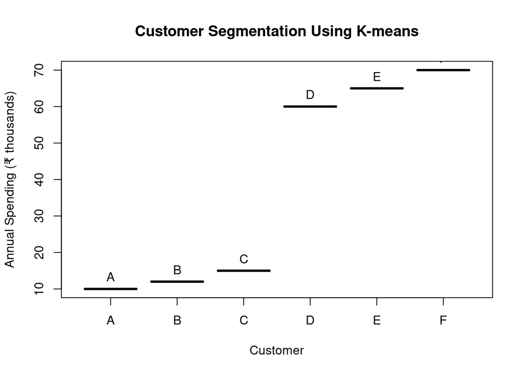

```r
plot(
  factor(customer$Customer),
  customer$Spending,
  col = model$cluster,
  pch = 19,
  main = "Customer Segmentation Using K-means",
  xlab = "Customer",
  ylab = "Annual Spending (₹ thousands)"
)

text(
  factor(customer$Customer),
  customer$Spending,
  labels = customer$Customer,
  pos = 3
)
```

## 6. Why is data preparation important in K-means?

Suppose a company has two customer attributes:

| Customer | Annual spending (₹) | Number of purchases |
| --- | --- | --- |
| A | 10,000 | 5 |
| B | 12,000 | 6 |
| C | 15,000 | 8 |

Annual spending has values in the thousands, while the number of purchases has much smaller values.

Because K-means commonly uses Euclidean distance, differences in spending could dominate the distance calculations.

For example, consider the distance between customers A and B:

$$d=\sqrt{(10000-12000)^2+(5-6)^2}$$
$$d\approx 2000$$

The difference in the number of purchases contributes very little compared with the difference in spending.

### Solution: Standardize the variables

In R, we can standardize numerical variables using `scale()`.

```r
customer_data <- data.frame(
  Spending = c(10000, 12000, 15000, 60000, 65000, 70000),
  Purchases = c(5, 6, 8, 25, 28, 30)
)

customer_scaled <- scale(customer_data)

customer_scaled
```

```
##        Spending  Purchases
## [1,] -0.9863579 -1.0141851
## [2,] -0.9175422 -0.9296697
## [3,] -0.8143187 -0.7606388
## [4,]  0.7340338  0.6761234
## [5,]  0.9060729  0.9296697
## [6,]  1.0781121  1.0987005
## attr(,"scaled:center")
##  Spending Purchases
##  38666.67     17.00
## attr(,"scaled:scale")
##    Spending   Purchases
## 29063.14963    11.83216
```

Standardization transforms each variable approximately to a mean of 0 and a standard deviation of 1.

We can then apply K-means:

```r
set.seed(123)

model <- kmeans(
  customer_scaled,
  centers = 2,
  nstart = 25
)

model$cluster
```

```
## [1] 1 1 1 2 2 2
```

## 7. How do we choose the value of K?

One of the main challenges with K-means is deciding how many clusters to create.

For example, should a company divide customers into 2, 3, 4, or 5 groups?

A commonly taught approach is the **elbow method**.

The basic idea is to run K-means for different values of K and examine how the within-cluster sum of squares changes.

- When K increases, the within-cluster sum of squares generally decreases.
- Initially, increasing K may substantially improve the clustering.
- Eventually, the improvement becomes smaller.
- The point where the decrease starts slowing noticeably is called the *elbow*.

That point can suggest a reasonable value of K, although the elbow is not always clear. Domain knowledge and the intended use of the clusters should also influence the choice.

## 8. What does K-means try to minimize?

K-means attempts to minimize the **within-cluster sum of squares (WCSS)**.

In simple terms, it tries to keep observations close to the centroid of their assigned cluster.

The objective function is:

$$WCSS=\sum_{k=1}^{K}\sum_{x_i\in C_k}
\|x_i-\mu_k\|^2$$

Where:

- $K$ = number of clusters
- $C_k$ = observations assigned to cluster $k$
- $x_i$ = an individual observation
- $\mu_k$ = centroid of cluster $k$
- $\|x_i-\mu_k\|^2$ = squared Euclidean distance from the observation to its centroid

In plain language, **K-means tries to form clusters in which observations are close to their respective cluster centers.**

## Advantages and limitations of K-means

| Advantages | Limitations |
| --- | --- |
| Easy to understand and implement | The number of clusters K must be selected in advance |
| Works well for many numerical datasets | Sensitive to initial centroid selection |
| Can handle relatively large datasets efficiently | Sensitive to outliers |
| Produces interpretable cluster centers | Results can be affected by variable scaling |
| Useful for exploratory data analysis | May perform poorly when clusters have irregular shapes or very different densities |

K-means is generally most suitable for numerical data where distance-based groups are meaningful. Categorical variables cannot simply be treated as ordinary numerical measurements without considering an appropriate representation and distance measure.

## K-means versus hierarchical clustering

| Feature | K-means | Hierarchical clustering |
| --- | --- | --- |
| Basic approach | Divides observations into K clusters | Builds a hierarchy of clusters |
| Number of clusters | Usually specified before fitting | Can be selected by cutting the resulting hierarchy |
| Main output | Cluster assignments and centroids | A hierarchy commonly visualized using a dendrogram |
| Typical distance-based process | Assigns observations to the nearest centroid | Merges or splits groups according to the selected method |
| Computational considerations | Often efficient for larger datasets | Can become expensive for large datasets, depending on the method |

### A simple way to explain the difference

Imagine a teacher wants to group 100 students based on their marks and attendance.

- **K-means:** The teacher decides to create three groups, and the algorithm assigns students to those groups.
- **Hierarchical clustering:** The algorithm builds a hierarchy showing how students or groups relate to one another. The teacher can later select a level at which to divide the hierarchy into clusters.

### hierarchical clustering in R

You can use different distance measures with `dist()`:

```r
x <- data.frame(
  Mathematics = c(60, 63, 80),
  Statistics = c(70, 74, 85)
)

# Euclidean distance
dist(x, method = "euclidean")
```

```
##          1        2
## 2  5.00000
## 3 25.00000 20.24846
```

```r
# Manhattan distance
dist(x, method = "manhattan")
```

```
##    1  2
## 2  7
## 3 35 28
```

```r
# Maximum distance
dist(x, method = "maximum")
```

```
##    1  2
## 2  4
## 3 20 17
```

```r
# Canberra distance
dist(x, method = "canberra")
```

```
##            1          2
## 2 0.05216802
## 3 0.23963134 0.18806351
```

R’s `dist()` also supports `"minkowski"` and `"binary"` methods, among others. The `"binary"` method calculates a binary dissimilarity measure; it is **not the same as Hamming distance** in general.

For cosine similarity and Hamming distance, we can calculate them directly as shown earlier or use suitable packages.

A distance measure tells us how dissimilar two observations are. Euclidean and Manhattan distances compare numerical differences, Hamming distance counts mismatches, and cosine similarity compares the directions of vectors. Choosing the appropriate measure is an important step in clustering.

# Hierarchical clustering

Hierarchical clustering is an **unsupervised learning technique** that groups similar observations into clusters.

There are two main approaches:

1. **Agglomerative clustering:** Bottom-up approach — repeatedly merges smaller clusters into larger clusters.
2. **Divisive clustering:** Top-down approach — repeatedly splits larger clusters into smaller clusters.

Let’s understand both using a simple customer-segmentation.

## 1. Agglomerative clustering (Bottom-up approach)

### Example: Grouping customers

Suppose an e-commerce company wants to group four customers based on their annual spending.

| Customer | Annual spending (₹ thousands) |
| --- | --- |
| A | 10 |
| B | 12 |
| C | 50 |
| D | 52 |

Customers A and B have similar spending, while customers C and D have similar spending.

Agglomerative clustering discovers these groups by starting with individual customers and progressively merging them.

### How does it work?

**Step 1: Initially, every customer forms a separate cluster.**

```
{A}   {B}   {C}   {D}
```

There are four clusters.

**Step 2: Merge the two closest customers.**

A and B differ by only 2 thousand rupees, so they can be merged.

**Step 3: Merge the next closest customers.**

C and D also differ by 2 thousand rupees.

Now there are two clusters.

**Step 4: Merge the remaining clusters.**

Eventually, all customers become part of one cluster.

```
{A, B, C, D}
```

The process continues until all observations are merged into one cluster, unless a stopping rule is used.

**Remember:** Agglomerative clustering starts with *many small clusters* and gradually produces *fewer, larger clusters*.

### R program: Agglomerative clustering

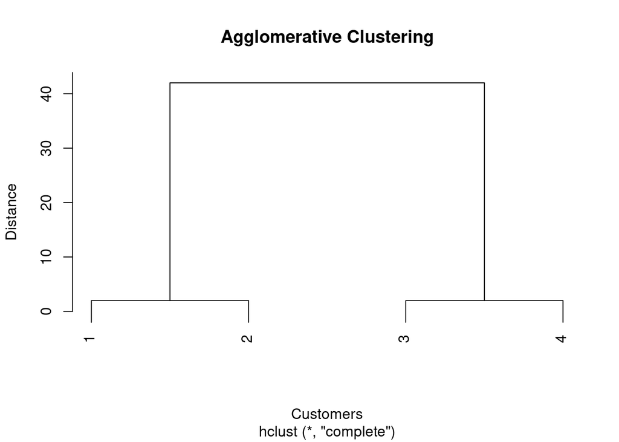

```r
# Create customer data
customer <- data.frame(
  Spending = c(10, 12, 50, 52)
)

# Step 1: Calculate distances
d <- dist(customer)

# Step 2: Perform agglomerative clustering
hc <- hclust(d, method = "complete")

# Step 3: Display the dendrogram
plot(hc, main = "Agglomerative Clustering",
     xlab = "Customers", ylab = "Distance")
```

```r
# Step 4: Divide into two clusters
groups <- cutree(hc, k = 2)

# Display cluster assignments
groups
```

```
## [1] 1 1 2 2
```

**Understanding the code:**

| R statement | Purpose |
| --- | --- |
| `dist(customer)` | Calculates distances between customers |
| `hclust(d, method = "complete")` | Performs agglomerative clustering using complete linkage |
| `plot(hc)` | Displays the dendrogram |
| `cutree(hc, k = 2)` | Extracts two clusters |

The expected grouping is:

| Customer | Spending | Cluster |
| --- | --- | --- |
| A | 10 | 1 |
| B | 12 | 1 |
| C | 50 | 2 |
| D | 52 | 2 |

The cluster numbers may be reversed; what matters is which customers are grouped together.

## 2. Divisive clustering (Top-down approach)

Divisive clustering follows the opposite approach.

Instead of starting with individual customers, **it starts with all customers in one cluster and progressively divides them into smaller clusters**.

### How does it work?

**Step 1: Initially, all customers belong to one cluster.**

{A, B, C, D}

**Step 2: Divide the customers into two groups.**

**Step 3: Continue splitting the groups.**

Each group can be divided further if necessary.

```
{A}   {B}   {C}   {D}
```

The process continues until a stopping condition is reached, such as every observation forming its own cluster.

**Remember:** Divisive clustering starts with *one large cluster* and gradually produces *smaller clusters*.

### R program: Divisive clustering

In R, the `cluster` package provides the `diana()` function, which performs divisive hierarchical clustering.

```r
# Install the package if necessary
# install.packages("cluster")

library(cluster)

# Create customer data
customer <- data.frame(
  Spending = c(10, 12,14, 50, 52)
)

# Step 1: Perform divisive clustering
div <- diana(customer)

print(div)
```

```
## Merge:
##      [,1] [,2]
## [1,]   -4   -5
## [2,]   -2   -3
## [3,]   -1    2
## [4,]    3    1
## Order of objects:
## [1] 1 2 3 4 5
## Height:
## [1]  4  2 42  2
## Divisive coefficient:
## [1] 0.9428571
##
## Available components:
## [1] "order"  "height" "dc"     "merge"  "diss"   "call"   "data"
```

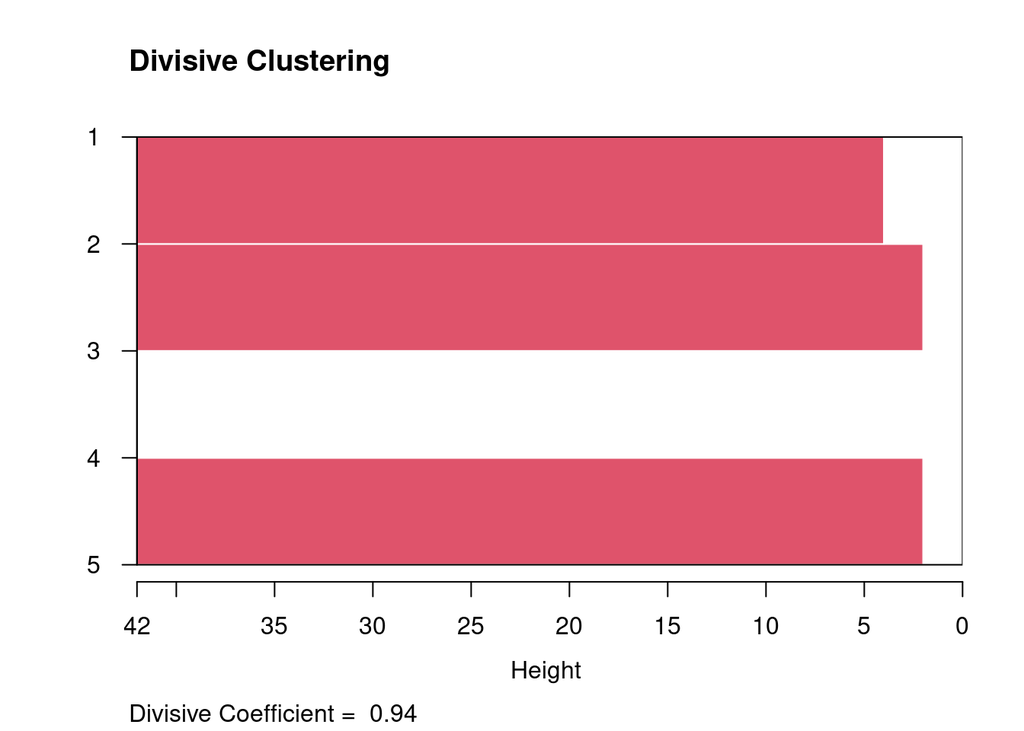

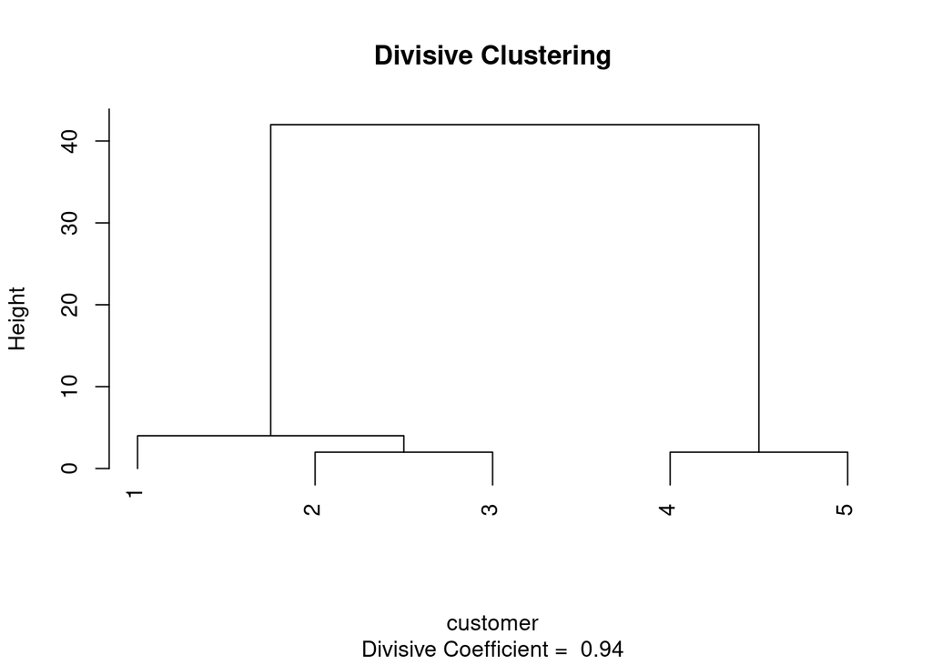

```r
# Step 2: Display the dendrogram
plot(div, main = "Divisive Clustering")
```

```r
# Step 3: Convert to hclust format
#div_hc <- as.hclust(div)

# Step 4: Extract two clusters
#groups <- cutree(div_hc, k = 2)

# Display cluster assignments
#groups
```

**Understanding the code:**

| R statement | Purpose |
| --- | --- |
| `library(cluster)` | Loads the package containing `diana()` |
| `diana(customer)` | Performs divisive hierarchical clustering |
| `plot(div)` | Displays the divisive clustering tree |
| `as.hclust(div)` | Converts the result to an `hclust` object |
| `cutree(div_hc, k = 2)` | Extracts two clusters |

Note that `diana()` uses its own divisive clustering procedure; it does not simply reverse the exact sequence produced by `hclust()`.

## 3. Agglomerative versus divisive clustering

| Feature | Agglomerative | Divisive |
| --- | --- | --- |
| Approach | Bottom-up | Top-down |
| Initial state | Every observation is a separate cluster | All observations belong to one cluster |
| Main operation | Merges clusters | Splits clusters |
| Direction | Small clusters → large clusters | Large clusters → small clusters |
| R function | `hclust()` | `diana()` |
| R package | Base R | `cluster` package |
| Visualization | Dendrogram | Dendrogram |

### Example

Think of a college.

- **Agglomerative:** Start with individual students and gradually combine similar students into groups, then combine groups into larger groups.
- **Divisive:** Start with all students together and repeatedly divide them into smaller groups based on similarities.

Both methods help discover relationships in data without predefined class labels.

### questions

1. What is the difference between agglomerative and divisive clustering?
2. Why is agglomerative clustering called a bottom-up approach?
3. Which R function performs divisive hierarchical clustering?
4. What is the purpose of `cutree()` in hierarchical clustering?